# [Rtips] tbl 자료형에서 소수점을 출력해보자

R

tbl

tibble

digit

options

options(pillar.sigfig=10) 함수는 tibble 자료형에서 소수점 자리수를 조절하는 기능을 제공합니다.

true  
2018-08-22

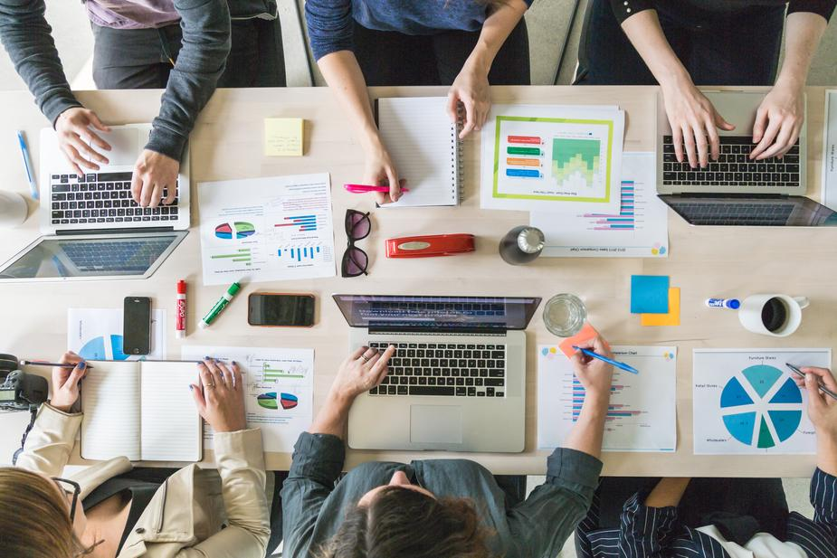

### 한줄요약

1. `options(pillar.sigfig=10)`

*tidyverse* 생태계는 R의 현재 부흥기를 이끌고 있습니다. *magrittr* 패키지가 쏘아올린 `%>%(파이프 연산자)`가 이렇게 될꺼라고 상상이나 했을까요. [해들리 위컴](http://hadley.nz/)이 발표한 [tidy data](http://vita.had.co.nz/papers/tidy-data.html)와 함께 *tidyverse*에서는 없는게 상상도 할 수 없는 것이 많습니다.

이런 *tidyverse*에서 data를 담당하는 패키지가 [tibble](https://tibble.tidyverse.org/)입니다.

[figure not shown]

[tibble](https://tibble.tidyverse.org/)은 `tbl`, `tbl_df` 등등의 자료형으로 표현됩니다. 위에 그림에도 보이는 것처럼 `data.frame`과 같은 역할을 하면서, 더 세련됬다고 할까요.

그 와중에 [tibble](https://tibble.tidyverse.org/)의 출력을 담당하는 패키지가 pillar입니다.

```r
# install.packages("pillar")
library(pillar)
x <- 123456789 * (10 ^ c(-3, -5, NA, -8, -10))
x
```

```
[1] 1.234568e+05 1.234568e+03           NA 1.234568e+00 1.234568e-02
```

```r
pillar(x)
```

```
      <dbl>
123457.
  1235.
    NA
     1.23
     0.0123
```

마크다운에는 디테일이 표현되지 않아 사진을 첨부합니다.

[figure not shown]

3자리 마다 쉼표로 표시하는 관행을 출력해주기 위해, pillar 패키지는 밑줄을 사용합니다. 보기 참 좋아진거 같습니다!

그러다 보니… 소수점 표기의 출력 옵션이 기존의 `data.frame`과 다릅니다. 찾아보니 `options(pillar.sigfig)`를 조절하면 된다는군요!

```r
options(pillar.sigfig)
## Error in options(pillar.sigfig) : object 'pillar.sigfig' not found
```

기본 값이 없는거 같습니다….(;;;) 패키지에는 3이 기본값이라고 하는데 어떻게 보는지 모르겠네요;;; 이젠 `tibble`에서 확인해 볼까요?

```r
my_numbers <-  c(233, 486, 565, 785)
tbl_num <- tibble::tibble(
  big = 1000 * my_numbers + 23,
  stradle = my_numbers / 1000 + 100,
  small = my_numbers / 100000
)
tbl_num
```

```
# A tibble: 4 x 3
     big stradle   small
   <dbl>   <dbl>   <dbl>
1 233023    100. 0.00233
2 486023    100. 0.00486
3 565023    101. 0.00565
4 785023    101. 0.00785
```

출력을 보면 stradle 컬럼의 첫번째 데이터가 `100.`라고 되어 있습니다. `100`이 아니고 `100.`이라고 출력해주면서 소수점 숫자가 있음을 알려주는데요. [관련 이슈](https://github.com/r-lib/pillar/issues/40#issuecomment-360152576)도 있으니 읽어보시면 좋을 것 같구요.

```r
options(pillar.sigfig = 7)
tbl_num
```

[output not shown]

pillar의 **sigfig** 옵션은 사실 소수점에 해당하는 옵션이 아닙니다. 유효숫자에 대한 옵션이죠. 유효숫자는 또 큰 주제니까 다음에 다루기로 하구요.

pillar에서는 [출력에 대한 옵션](https://pillar.r-lib.org/reference/pillar-package.html#package-options)을 제공하고 있습니다.

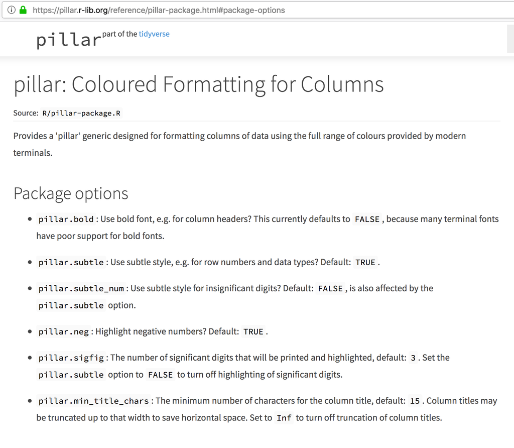

한번 읽어보시면 취향껏 고치는데 도움이 되지 않을까요?ㅎㅎ

감사합니다.